# ViralProduction_Workflow

Hisham M Shaikh

2022-06-17

**1. Setting up working directory**

**2. Installing libraries**  
We can simply source the `0_vp_source.R` script

```r
source("0_vp_source.R")
```

[output not shown]

**3. Extracting Counts from FCS files**  
The script, `1_input_data_counts.R`, reads the FCS files and extracts count information on the following:  
1. Total Count  
2. Total Bacteria  
3. Total Viruses  
4. HNA Bacteria  
5. LNA Bacteria  
6. V1 Viruses  
7. V2 Viruses  
8. V3 Viruses  
The output is saved as a `.csv` file  
**4. Data wrangling and metadata**  
The script, `2_data_wrangling_TE`, takes the input `.csv` file, adds the metadata, and corrects for TE.  
The output of this is another `.csv` file.  
This `.csv` file can be used for plotting and extracting downstream information.  
**5. Generating Plots**  
Here we try to get an overview plot from the `.csv` generated in Step 4.  
We’ll first generate a plot from averaged values for VP and VPC. We’ll subtract VP from VPC to calculate the Difference curve. We will then add the SD to get the SD for the Diff curve.

Th function `overview_df_tp_avg` converts the `.csv` file into a dataframe that could be used by the overview plot function. I still need to work on this function. I need to figure out the bacterial production endpoint first for this.

[output not shown]

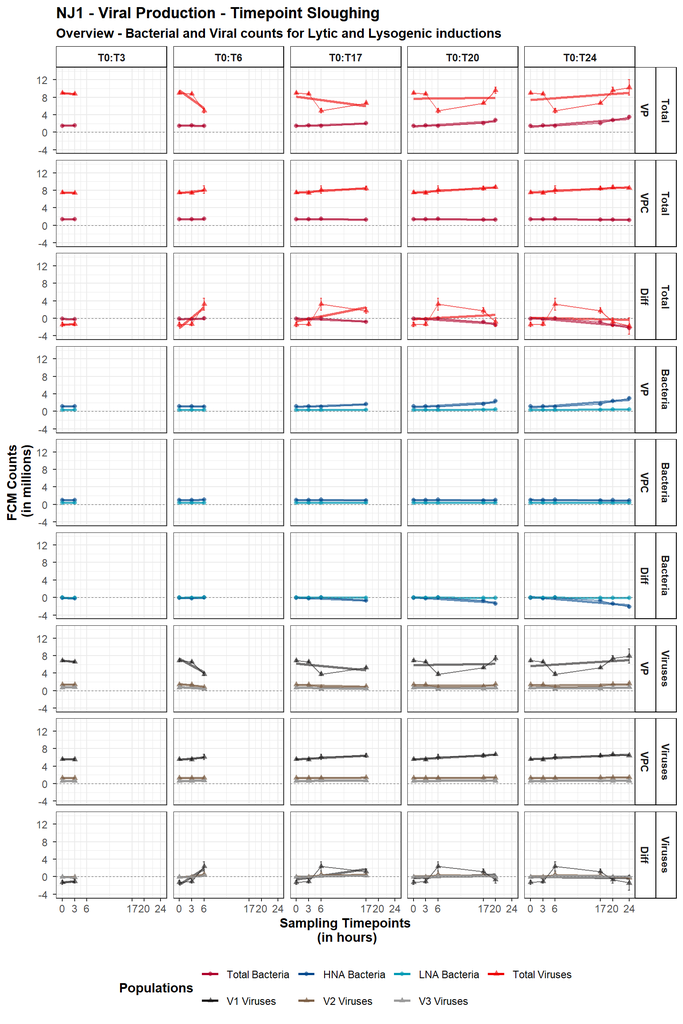

```r
NJ1<- read.csv("NJ1.csv")
overview_df_tp_avg(NJ1)%>%
  overview_plots_tp_avg()
```